# Credit Card Customer Segmentation

**Background:** AllLife Bank wants to focus on its credit card customer base in the next financial year. They have been advised by their marketing research team, that the penetration in the market can be improved. Based on this input, the Marketing team proposes to run personalised campaigns to target new customers as well as upsell to existing customers. Another insight from the market research was that the customers perceive the support services of the back poorly. Based on this, the Operations team wants to upgrade the service delivery model, to ensure that customers queries are resolved faster. Head of Marketing and Head of Delivery both decide to reach out to the Data Science team for help.

**Objective:** To identify different segments in the existing customer based on their spending patterns as well as past interaction with the bank.

**Data Description**: Data is of various customers of a bank with their credit limit, the total number of credit cards the customer has, and different channels through which customer has contacted the bank for any queries, different channels include visiting the bank, online and through a call.

- Customer key - Identifier for the customer
- Average Credit Limit - Average credit limit across all the credit cards
- Total credit cards - Total number of credit cards
- Total visits bank - Total number of bank visits
- Total visits online - total number of online visits
- Total calls made - Total number of calls made by the customer

```python
import warnings
warnings.filterwarnings('ignore')

import numpy as np
import pandas as pd
from sklearn.preprocessing import StandardScaler
import matplotlib.pyplot as plt

%matplotlib inline
import seaborn as sns

from matplotlib import animation
from mpl_toolkits.mplot3d import  Axes3D

from sklearn.cluster import KMeans
from scipy.spatial.distance import cdist

from sklearn.metrics import silhouette_score

from scipy.stats import zscore
```

**Perform univariate analysis on the data to better understand the variables at your disposal and to get an idea about the no of clusters. Perform EDA, create visualizations to explore data.**

```python
# Read excel data

excel = pd.ExcelFile('Credit Card Customer Data.xlsx')
excel.sheet_names
cccs_df = excel.parse("Sheet1", index_col=0)
cccs_df.head()
```

| Sl_No | Customer Key | Avg_Credit_Limit | Total_Credit_Cards | Total_visits_bank | Total_visits_online | Total_calls_made |
| --- | --- | --- | --- | --- | --- | --- |
| 1 | 87073 | 100000 | 2 | 1 | 1 | 0 |
| 2 | 38414 | 50000 | 3 | 0 | 10 | 9 |
| 3 | 17341 | 50000 | 7 | 1 | 3 | 4 |
| 4 | 40496 | 30000 | 5 | 1 | 1 | 4 |
| 5 | 47437 | 100000 | 6 | 0 | 12 | 3 |

```python
cccs_df.shape
```

```
(660, 6)
```

```python
cccs_df.info()
```

```
<class 'pandas.core.frame.DataFrame'>
Int64Index: 660 entries, 1 to 660
Data columns (total 6 columns):
 #   Column               Non-Null Count  Dtype
---  ------               --------------  -----
 0   Customer Key         660 non-null    int64
 1   Avg_Credit_Limit     660 non-null    int64
 2   Total_Credit_Cards   660 non-null    int64
 3   Total_visits_bank    660 non-null    int64
 4   Total_visits_online  660 non-null    int64
 5   Total_calls_made     660 non-null    int64
dtypes: int64(6)
memory usage: 36.1 KB
```

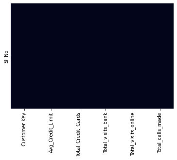

```python
# Visualiation of misssing value in heat map

sns.heatmap(cccs_df.isnull(),yticklabels=False,cbar=False)
```

```python
# Summary

cccs_df.describe().transpose()
```

|  | count | mean | std | min | 25% | 50% | 75% | max |
| --- | --- | --- | --- | --- | --- | --- | --- | --- |
| Customer Key | 660.0 | 55141.443939 | 25627.772200 | 11265.0 | 33825.25 | 53874.5 | 77202.5 | 99843.0 |
| Avg_Credit_Limit | 660.0 | 34574.242424 | 37625.487804 | 3000.0 | 10000.00 | 18000.0 | 48000.0 | 200000.0 |
| Total_Credit_Cards | 660.0 | 4.706061 | 2.167835 | 1.0 | 3.00 | 5.0 | 6.0 | 10.0 |
| Total_visits_bank | 660.0 | 2.403030 | 1.631813 | 0.0 | 1.00 | 2.0 | 4.0 | 5.0 |
| Total_visits_online | 660.0 | 2.606061 | 2.935724 | 0.0 | 1.00 | 2.0 | 4.0 | 15.0 |
| Total_calls_made | 660.0 | 3.583333 | 2.865317 | 0.0 | 1.00 | 3.0 | 5.0 | 10.0 |

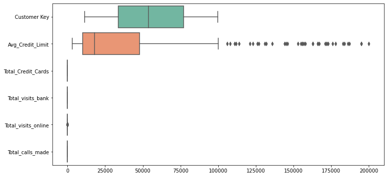

```python
# Checking the presence of outliers

plt.figure(figsize=(12,6))
sns.boxplot(data=cccs_df, orient="h", palette="Set2", dodge=False)
```

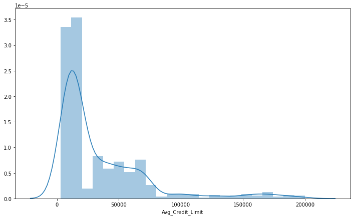

```python
# KDE plot for all the features to see how many of it can show separate clusters.
# Average credit limit

plt.figure(figsize=(12,7))
sns.distplot(cccs_df.Avg_Credit_Limit);
```

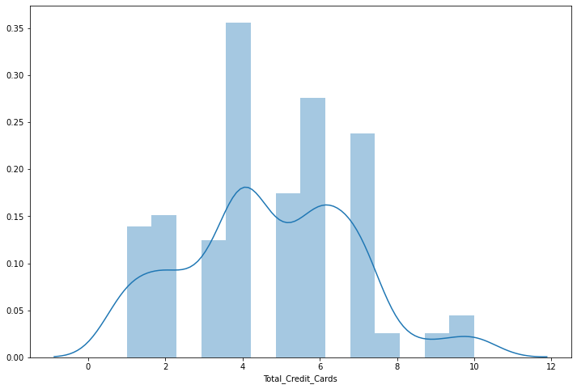

```python
# Total credit cards:

plt.figure(figsize=(12,8))
sns.distplot(cccs_df.Total_Credit_Cards);
```

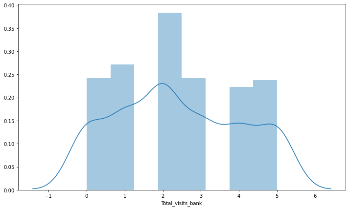

```python
# Total bank visits

plt.figure(figsize=(12,7))
sns.distplot(cccs_df.Total_visits_bank);
```

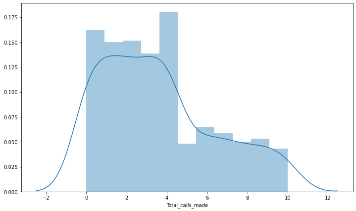

```python
# Total calls made

plt.figure(figsize=(12,7))
sns.distplot(cccs_df.Total_calls_made);
```